# Yelp_Customer_Review_Capstone

## Machine Learning Capstone - Arunprakash Nagarajan

### Sentiment Analysis on Yelp data

```python
# Import libraries necessary for this project
import numpy as np
import pandas as pd
from time import time
from IPython.display import display # Allows the use of display() for DataFrames
import matplotlib.pyplot as plt
import seaborn as sns
import nltk
nltk.download('stopwords')

# Pretty display for notebooks
%matplotlib inline

# Load the Census dataset
data = pd.read_csv("yelp.csv")

# Success - Display the first record
display(data.head())
```

|  | business_id | date | review_id | stars | text | type | user_id | cool | useful | funny |
| --- | --- | --- | --- | --- | --- | --- | --- | --- | --- | --- |
| 0 | 9yKzy9PApeiPPOUJEtnvkg | 2011-01-26 | fWKvX83p0-ka4JS3dc6E5A | 5 | My wife took me here on my birthday for breakf... | review | rLtl8ZkDX5vH5nAx9C3q5Q | 2 | 5 | 0 |
| 1 | ZRJwVLyzEJq1VAihDhYiow | 2011-07-27 | IjZ33sJrzXqU-0X6U8NwyA | 5 | I have no idea why some people give bad review... | review | 0a2KyEL0d3Yb1V6aivbIuQ | 0 | 0 | 0 |
| 2 | 6oRAC4uyJCsJl1X0WZpVSA | 2012-06-14 | IESLBzqUCLdSzSqm0eCSxQ | 4 | love the gyro plate. Rice is so good and I als... | review | 0hT2KtfLiobPvh6cDC8JQg | 0 | 1 | 0 |
| 3 | _1QQZuf4zZOyFCvXc0o6Vg | 2010-05-27 | G-WvGaISbqqaMHlNnByodA | 5 | Rosie, Dakota, and I LOVE Chaparral Dog Park!!... | review | uZetl9T0NcROGOyFfughhg | 1 | 2 | 0 |
| 4 | 6ozycU1RpktNG2-1BroVtw | 2012-01-05 | 1uJFq2r5QfJG_6ExMRCaGw | 5 | General Manager Scott Petello is a good egg!!!... | review | vYmM4KTsC8ZfQBg-j5MWkw | 0 | 0 | 0 |

```python
data
```

[output not shown]

10000 rows × 10 columns

```python
#Getting basic statistics of the data
```

```python
data.info()
```

```
<class 'pandas.core.frame.DataFrame'>
RangeIndex: 10000 entries, 0 to 9999
Data columns (total 10 columns):
business_id    10000 non-null object
date           10000 non-null object
review_id      10000 non-null object
stars          10000 non-null int64
text           10000 non-null object
type           10000 non-null object
user_id        10000 non-null object
cool           10000 non-null int64
useful         10000 non-null int64
funny          10000 non-null int64
dtypes: int64(4), object(6)
memory usage: 781.3+ KB
```

```python
data.describe()
```

|  | stars | cool | useful | funny |
| --- | --- | --- | --- | --- |
| count | 10000.000000 | 10000.000000 | 10000.000000 | 10000.000000 |
| mean | 3.777500 | 0.876800 | 1.409300 | 0.701300 |
| std | 1.214636 | 2.067861 | 2.336647 | 1.907942 |
| min | 1.000000 | 0.000000 | 0.000000 | 0.000000 |
| 25% | 3.000000 | 0.000000 | 0.000000 | 0.000000 |
| 50% | 4.000000 | 0.000000 | 1.000000 | 0.000000 |
| 75% | 5.000000 | 1.000000 | 2.000000 | 1.000000 |
| max | 5.000000 | 77.000000 | 76.000000 | 57.000000 |

```python
for i in range(1,6):
    print("the shape for the records which has ",i," star ratings",data[data['stars']== i].shape[0])
    data_i = data[data['stars']==i]
```

```
the shape for the records which has  1  star ratings 749
the shape for the records which has  2  star ratings 927
the shape for the records which has  3  star ratings 1461
the shape for the records which has  4  star ratings 3526
the shape for the records which has  5  star ratings 3337
```

### Exploratory Text Analysis before cleaning the text

```python
#Creating a copy of the data for analysis
rev = pd.read_csv("yelp.csv")
```

#### 1. Word Count : One of the most basic features we can extract is the number of words in reviews. The basic intuition behind this is that generally, the negative sentiments contain a lesser amount of words than the positive ones. Lets see how that intution goes about.

```python
#Number of words
rev['word_count'] = rev['text'].apply(lambda x: len(str(x).split(" ")))
rev[['word_count','text']].head()
```

|  | word_count | text |
| --- | --- | --- |
| 0 | 160 | My wife took me here on my birthday for breakf... |
| 1 | 256 | I have no idea why some people give bad review... |
| 2 | 16 | love the gyro plate. Rice is so good and I als... |
| 3 | 75 | Rosie, Dakota, and I LOVE Chaparral Dog Park!!... |
| 4 | 85 | General Manager Scott Petello is a good egg!!!... |

```
The average word count for reviews with  1  star is 156.013351135
The average word count for reviews with  2  star is 158.508090615
The average word count for reviews with  3  star is 143.043805613
The average word count for reviews with  4  star is 132.921440726
The average word count for reviews with  5  star is 116.054839676
```

```
Text(0.5,1,'Average Word count of reviews with different star ratings')
```

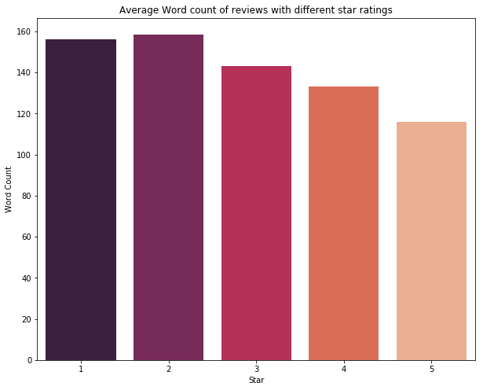

```python
wd = []
for i in range(1,6):
    wd1 = rev[rev['stars']== i]['word_count'].mean()
    print("The average word count for reviews with ",i," star is",rev[rev['stars']== i]['word_count'].mean())
    wd.append(wd1)
str1 = ['1','2','3','4','5']
plt.figure(figsize = (10, 8))
sns.barplot(str1,wd,palette="rocket")
plt.xlabel('Star')
plt.ylabel('Word Count')
plt.title('Average Word count of reviews with different star ratings')
```

#### Against our intuition people have written more for the negative reviews than for the positive comments

#### 2. Number of characters, is pretty same as the word count, the more word count is the more charcter count would be as well.

```python
rev['char_count'] = rev['text'].str.len() ## this also includes spaces
rev[['text','char_count']].head()
for i in range(1,6):
    cl = rev[rev['stars']== i]['char_count'].mean()
    print("The average character count for reviews with ",i," star is",rev[rev['stars']== i]['char_count'].mean())
```

```
The average character count for reviews with  1  star is 826.515353805
The average character count for reviews with  2  star is 842.256742179
The average character count for reviews with  3  star is 758.498288843
The average character count for reviews with  4  star is 712.923142371
The average character count for reviews with  5  star is 624.999100989
```

```
Text(0.5,1,'Text length vs stars')
```

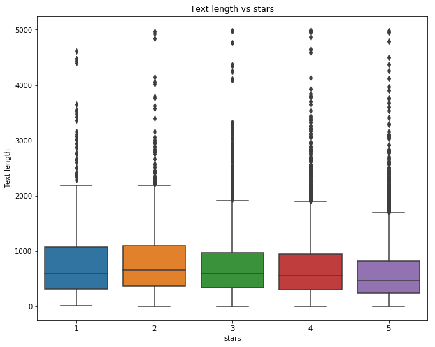

```python
rev['text_length'] = rev['text'].apply(len)
plt.figure(figsize = (10, 8))
sns.boxplot(x='stars', y='text_length', data=rev)
plt.xlabel('stars')
plt.ylabel('Text length')
plt.title('Text length vs stars')
```

#### 3. Average word length is an important for helping in improving our model.

```
The average character count for reviews with  1  star is 4.40925946268
The average character count for reviews with  2  star is 4.38404834886
The average character count for reviews with  3  star is 4.37949472048
The average character count for reviews with  4  star is 4.44716125621
The average character count for reviews with  5  star is 4.5173536425
```

```
Text(0.5,1,'Average Word length of reviews with different star ratings')
```

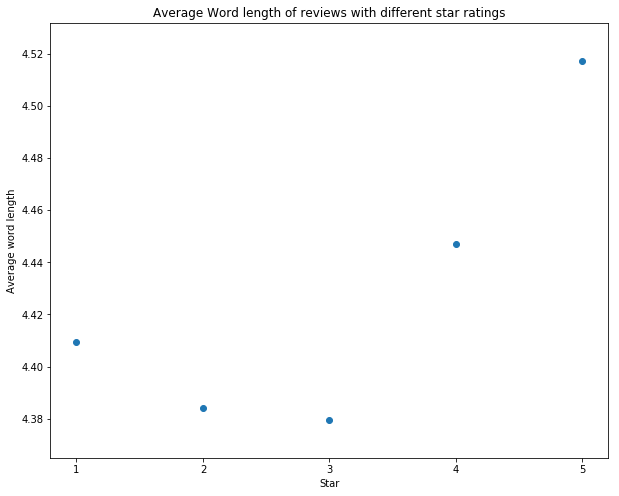

```python
def avg_word(sentence):
  words = sentence.split()
  return (sum(len(word) for word in words)/len(words))

rev['avg_word'] = rev['text'].apply(lambda x: avg_word(x))
rev[['text','avg_word']].head()

aw = []
for i in range(1,6):
    cl = rev[rev['stars']== i]['avg_word'].mean()
    print("The average character count for reviews with ",i," star is",rev[rev['stars']== i]['avg_word'].mean())
    aw.append(cl)
str1 = ['1','2','3','4','5']
plt.figure(figsize = (10, 8))
plt.scatter(str1,aw)
plt.xlabel('Star')
plt.ylabel('Average word length')
plt.title('Average Word length of reviews with different star ratings')
```

#### There is no much difference between the different average word length for the different star rated reviews.

#### 4. Analyzing the number of stop words. I will be using the nltk package english package to analyze the stop words.

```python
from nltk.corpus import stopwords
stop = stopwords.words('english')

rev['stop_words'] = rev['text'].apply(lambda x: len([x for x in x.split() if x in stop]))
```

```
The average stopwords count for reviews with  1  star is 63.8958611482
The average stopwords count for reviews with  2  star is 65.0949298813
The average stopwords count for reviews with  3  star is 57.7405886379
The average stopwords count for reviews with  4  star is 52.9461145774
The average stopwords count for reviews with  5  star is 45.7671561283
```

```
Text(0.5,1,'Average Stop word count for reviews with different star ratings')
```

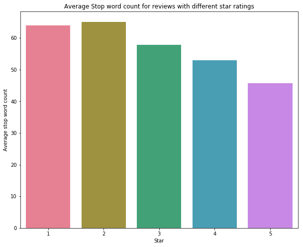

```python
sw = []
for i in range(1,6):
    sw1 = rev[rev['stars']== i]['stop_words'].mean()
    print("The average stopwords count for reviews with ",i," star is",rev[rev['stars']== i]['stop_words'].mean())
    sw.append(sw1)
str1 = ['1','2','3','4','5']
plt.figure(figsize = (10, 8))
sns.barplot(str1,sw,palette='husl')
plt.xlabel('Star')
plt.ylabel('Average stop word count')
plt.title('Average Stop word count for reviews with different star ratings')
```

#### 5. Number of numeric characters used. Like calculating the number of words, we can calculate the number of numeric characters which are present in the reviews.

```
The count of numeric characters for reviews with  1  star is 664
The count of numeric characters for reviews with  2  star is 685
The count of numeric characters for reviews with  3  star is 929
The count of numeric characters for reviews with  4  star is 1688
The count of numeric characters for reviews with  5  star is 1311
```

```
Text(0.5,1,'Count of numeric characters used in reviews with different star ratings')
```

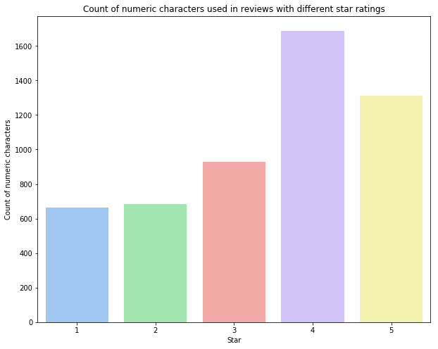

```python
rev['numerics'] = rev['text'].apply(lambda x: len([x for x in x.split() if x.isdigit()]))
rev[['text','numerics']].head()
nm=[]
for i in range(1,6):
    nm1 = rev[rev['stars']== i]['numerics'].sum()
    print("The count of numeric characters for reviews with ",i," star is",rev[rev['stars']== i]['numerics'].sum())
    nm.append(nm1)
str1 = ['1','2','3','4','5']
plt.figure(figsize = (10, 8))
sns.barplot(str1,nm,palette='pastel')
plt.xlabel('Star')
plt.ylabel('Count of numeric characters')
plt.title('Count of numeric characters used in reviews with different star ratings')
```

#### 6. Analyzing uppercase words, People generally use Uppercase words when they are extremely angry, so we can analyze the text for the uppercase to see few examples if our intuition is correct.

```python
rev['upper'] = rev['text'].apply(lambda x: len([x for x in x.split() if x.isupper()]))
rev[['text','upper','stars']].sort_values('upper',ascending=False).head(n=10)
```

|  | text | upper | stars |
| --- | --- | --- | --- |
| 4838 | Let me start off by saying that if there were ... | 100 | 5 |
| 6587 | I don't get it!!\nMy husband, daughter and I w... | 63 | 2 |
| 7972 | I noticed the sign for Shakey Jake's before it... | 57 | 3 |
| 7917 | So, not following my own advice (ahem, NEVER R... | 51 | 1 |
| 2674 | I'm sorry to be what seems to be the lone one ... | 51 | 1 |
| 2604 | Your reviews are hilarious!! (shoot--who was... | 50 | 1 |
| 9000 | The food...delicious. The atmosphere...relaxin... | 45 | 3 |
| 2487 | I am a bonafide book junkie. Libraries are my ... | 44 | 3 |
| 6611 | Wow. Wow Freakin' Wow.\n\nI have never, ever h... | 44 | 5 |
| 5504 | Reasons to Heart: Breakfast All Day, Self-Serv... | 39 | 4 |

#### Analyzing the 10 comments which use more uppercase in the reviews can be seen that only three comments are positive, where people are using uppercase to express happiness but there are more negative comments which is close to our intuition.

#### 7. Similarity matrix plot for the correlation. Grouping the data by the star rating to find a correlation between features such as cool, useful, and funny which we have not used so far.

```python
star = rev.groupby('stars').mean()
star.corr()
```

|  | cool | useful | funny | word_count | char_count | text_length | avg_word | stop_words | numerics | upper |
| --- | --- | --- | --- | --- | --- | --- | --- | --- | --- | --- |
| cool | 1.000000 | -0.743329 | -0.944939 | -0.865650 | -0.857664 | -0.857664 | 0.665737 | -0.873388 | -0.982977 | -0.986854 |
| useful | -0.743329 | 1.000000 | 0.894506 | 0.690255 | 0.699881 | 0.699881 | -0.277302 | 0.702006 | 0.749166 | 0.813966 |
| funny | -0.944939 | 0.894506 | 1.000000 | 0.844066 | 0.843461 | 0.843461 | -0.543185 | 0.850757 | 0.951953 | 0.977451 |
| word_count | -0.865650 | 0.690255 | 0.844066 | 1.000000 | 0.999648 | 0.999648 | -0.886465 | 0.999624 | 0.932553 | 0.907341 |
| char_count | -0.857664 | 0.699881 | 0.843461 | 0.999648 | 1.000000 | 1.000000 | -0.880262 | 0.999247 | 0.927022 | 0.903207 |
| text_length | -0.857664 | 0.699881 | 0.843461 | 0.999648 | 1.000000 | 1.000000 | -0.880262 | 0.999247 | 0.927022 | 0.903207 |
| avg_word | 0.665737 | -0.277302 | -0.543185 | -0.886465 | -0.880262 | -0.880262 | 1.000000 | -0.878341 | -0.753061 | -0.678162 |
| stop_words | -0.873388 | 0.702006 | 0.850757 | 0.999624 | 0.999247 | 0.999247 | -0.878341 | 1.000000 | 0.936284 | 0.913510 |
| numerics | -0.982977 | 0.749166 | 0.951953 | 0.932553 | 0.927022 | 0.927022 | -0.753061 | 0.936284 | 1.000000 | 0.992900 |
| upper | -0.986854 | 0.813966 | 0.977451 | 0.907341 | 0.903207 | 0.903207 | -0.678162 | 0.913510 | 0.992900 | 1.000000 |

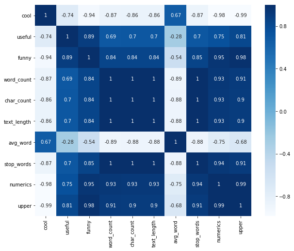

```python
plt.figure(figsize = (10, 8))
sns.heatmap(data=star.corr(), annot=True,cmap="Blues")
```

#### It can be noticed that useful, funny has high correlation interms of columns.